# Impact of extreme weather events on the economy and public health of the US

Extreme weather conditions can cause a great economic and health problems in communities. Some of them may cause injuries, property damage and even fatalities. This project explores the U.S National Oceanic and Atmospheric Administration’s storm database (1950-2011) to understand some of the most harmful events.

## Synopsis

The analysis is focus in answering two questions: i) Across the United States, which types of events (as indicated in the EVTYPE variable) are most harmful with respect to population health? and ii) Across the United States, which types of events have the greatest economic consequences?

In which the conclussions are the following:

1. Tornado is the most harmful event with respect to Population Health.
2. Floods have caused great economic impact.

## Data Processing

This analysis was perform using the Storm Events database provided by [National Climatic Data Center](http://www.ncdc.noaa.gov/). The data is from a comma-separated-value file available [here](https://d396qusza40orc.cloudfront.net/repdata%2Fdata%2FStormData.csv.bz2). Also there is some documentation about the data following this link https://d396qusza40orc.cloudfront.net/repdata%2Fpeer2_doc%2Fpd01016005curr.pdf.

1. Downloading the dataset:

```r
setwd('D:/02 Coursera/02 R/01 Johns Hopkings-Coursera/05 Reproducible Research')
download.file("http://d396qusza40orc.cloudfront.net/repdata%2Fdata%2FStormData.csv.bz2",destfile = "StormData.csv.bz2")
RawData <- read.csv(bzfile('StormData.csv.bz2'), sep = ',', header = TRUE,na.strings = 'NA')
```

2. Definining the 48 events described in the documentation:

```r
events <- c("Astronomical Low Tide", "Avalanche", "Blizzard", "Coastal Flood", "Cold/Wind Chill", "Debris Flow", "Dense Fog", "Dense Smoke", "Drought", "Dust Devil", "Dust Storm", "Excessive Heat", "Extreme cold/Wind Chill", "Flash Flood", "Flood", "Freezing", "Frost/Freeze", "Funnel Cloud", "Hail", "Heat", "Heavy Rain", "Heavy Snow", "High Surf", "High Wind", "Hurricane/Typhoon", "Ice Storm", "Lakeshore Flood", "Lake-Effect Snow", "Lightning", "Marine Hail", "Marine High Wind", "Marine Strong Wind", "Marine Thunderstorm Wind", "Rip Current", "Seiche", "Sleet", "Storm Tide", "Strong Wind", "Thunderstorm Wind", "Tornado", "Tropical Depression", "Tropical Storm", "Tsunami", "Volcanic Ash", "Waterspout", "Wildfire", "Winter Storm", "Winter Weather")

events_2 <- c("Astronomical Low Tide|Low Tide", "Avalanche", "Blizzard", "Coastal Flood", "Cold/Wind Chill", "Debris Flow", "Dense Fog", "Dense Smoke", "Drought", "Dust Devil", "Dust Storm", "Excessive Heat", "Extreme cold/Wind Chill|Extreme Cold|Wind Chill", "Flash Flood", "Flood", "Freezing", "Frost/Freeze|Frost|Freeze", "Funnel Cloud", "Hail", "Heat", "Heavy Rain", "Heavy Snow", "High Surf", "High Wind", "Hurricane/Typhoon|Hurricane|Typhoon", "Ice Storm", "Lakeshore Flood", "Lake-Effect Snow", "Lightning", "Marine Hail", "Marine High Wind", "Marine Strong Wind", "Marine Thunderstorm Wind|Marine tstm Wind", "Rip Current", "Seiche", "Sleet", "Storm Tide", "Strong Wind", "Thunderstorm Wind|tstm wind", "Tornado", "Tropical Depression", "Tropical Storm", "Tsunami", "Volcanic Ash", "Waterspout", "Wildfire", "Winter Storm", "Winter Weather")
```

3. Creating empty vector for the variables that we need in order to add some values later on:

```r
options(scipen = 999)
EVTYPE <- character()
FATALITIES <- numeric()
INJURIES <- numeric()
PROPDMG <- numeric()
PROPDMGEXP <- character()
CROPDMG <- numeric()
CROPDMGEXP <- character()
```

4. Creating an empty dataframe with the names of the vectors from above:

```r
ProcData <- data.frame(EVTYPE,FATALITIES,INJURIES,PROPDMG,PROPDMGEXP,CROPDMG,CROPDMGEXP)
```

5. Adding values to the new Processed Data (ProcData) by doing a for loop through all observations

```r
for (i in 1:length(events)){
  rows <- RawData[grep(events_2[i],RawData$EVTYPE,ignore.case = TRUE),]
  rows <- rows[,c("EVTYPE","FATALITIES","INJURIES","PROPDMG","PROPDMGEXP","CROPDMG","CROPDMGEXP")]
  Names <- c(rep(events[i],nrow(rows)))
  rows <- cbind(rows,Names)
  ProcData <- rbind(ProcData,rows)
}
```

6. Replacing characters with numbers in order to do compute the magnitude. First we need to make sure our vectors are characters otherwise an error will come up.

```r
ProcData$CROPDMGEXP <- as.character(ProcData$CROPDMGEXP)
ProcData$PROPDMGEXP <- as.character(ProcData$PROPDMGEXP)

ProcData[(ProcData$PROPDMGEXP == "K" | ProcData$PROPDMGEXP == "k"), ]$PROPDMGEXP <- 3

ProcData[(ProcData$PROPDMGEXP == "M" | ProcData$PROPDMGEXP == "m"), ]$PROPDMGEXP <- 6

ProcData[(ProcData$PROPDMGEXP == "B" | ProcData$PROPDMGEXP == "b"), ]$PROPDMGEXP <- 9

ProcData[(ProcData$CROPDMGEXP == "K" | ProcData$CROPDMGEXP == "k"), ]$CROPDMGEXP <- 3

ProcData[(ProcData$CROPDMGEXP == "M" | ProcData$CROPDMGEXP == "m"), ]$CROPDMGEXP <- 6

ProcData[(ProcData$CROPDMGEXP == "B" | ProcData$CROPDMGEXP == "b"), ]$CROPDMGEXP <- 9
```

7. Compute the economic damage (PROPDMGEXP + CROPDMGEXP)

```r
suppressWarnings(ProcData$PROPDMG <- ProcData$PROPDMG * 10^as.numeric(ProcData$PROPDMGEXP))
suppressWarnings(ProcData$CROPDMG <- ProcData$CROPDMG * 10^as.numeric(ProcData$CROPDMGEXP))
suppressWarnings(ProcData$TOTAL_ECODMG <- ProcData$PROPDMG + ProcData$CROPDMG)
ProcData <- ProcData[, c("EVTYPE", "FATALITIES", "INJURIES", "PROPDMG", "CROPDMG", "Names", "TOTAL_ECODMG")]
```

## Results

1. Across the United States, which types of events are most harmful with respect to population health? In terms of fatalities we have:

```r
library(ggplot2)
GroupFatalities <- aggregate(FATALITIES~Names,data=ProcData,FUN = sum)
GroupFatalities <- GroupFatalities[order(GroupFatalities$FATALITIES,decreasing = TRUE),]
TopFatalities <- GroupFatalities[1:10,]
print(TopFatalities)
```

```
##                      Names FATALITIES
## 38                 Tornado       5661
## 19                    Heat       3138
## 11          Excessive Heat       1922
## 14                   Flood       1525
## 13             Flash Flood       1035
## 28               Lightning        817
## 37       Thunderstorm Wind        753
## 33             Rip Current        577
## 12 Extreme cold/Wind Chill        382
## 23               High Wind        299
```

In terms of injuries we have:

```r
GroupInjuries <- aggregate(INJURIES~Names,data=ProcData,FUN = sum)
GroupInjuries <- GroupInjuries[order(GroupInjuries$INJURIES,decreasing = TRUE),]
TopInjuries <- GroupInjuries[1:10,]
print(TopInjuries)
```

```
##                Names INJURIES
## 38           Tornado    91407
## 37 Thunderstorm Wind     9493
## 19              Heat     9224
## 14             Flood     8604
## 11    Excessive Heat     6525
## 28         Lightning     5232
## 25         Ice Storm     1992
## 13       Flash Flood     1802
## 23         High Wind     1523
## 18              Hail     1467
```

2. Across the United States, which types of events have the greatest economic consequences?

```r
TotalEcoDmg <- aggregate(TOTAL_ECODMG~Names,data=ProcData,FUN = sum)
TotalEcoDmg <- TotalEcoDmg[order(TotalEcoDmg$TOTAL_ECODMG,decreasing = TRUE),]
TopEconDmg <- TotalEcoDmg[1:10,]
print(TopEconDmg)
```

```
##                Names TOTAL_ECODMG
## 14             Flood 157764680787
## 24 Hurricane/Typhoon  44330000800
## 38           Tornado  18172843863
## 18              Hail  11681050140
## 13       Flash Flood   9224527227
## 37 Thunderstorm Wind   7098296330
## 25         Ice Storm   5925150850
## 44          Wildfire   3685468370
## 23         High Wind   3472442200
## 8            Drought   1886667000
```

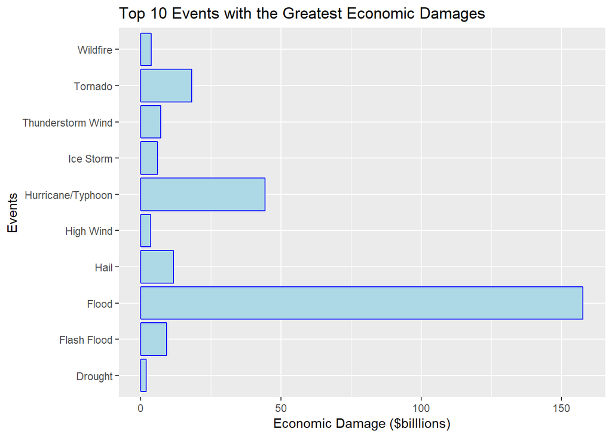

```r
ggplot(TopEconDmg,aes(Names,TOTAL_ECODMG/(10^9))) + geom_bar(stat = "identity",color = "blue",fill = "lightblue") + coord_flip() + ggtitle("Top 10 Events with the Greatest Economic Damages") + labs(x="Events",y = "Economic Damage ($billlions)")
```